# Red Wine EDA

(Udacity Data Analyst Project)

I Gede W. Cakramurti

1. Opening
1. Introduction
2. Data Pre-processing
2. Exploratory Data Analysis
1. Univariate Plot
2. Bivariate Plot
3. Multivariate Plot
3. Linear Model
4. Final Conclusion
5. Reflection

# 1. Opening

## a. Introduction

This project is an exploratory data analysis (EDA) on red wine dataset created by Paulo Cortez. The variables in this data are the attributes of red wine (e.g. pH value, acidity, residual sugar, and others) and the quality of the wine (rated from 0 - 10). For more information about the attributes, please read [Cortez et al., 2009].

We would like to know more about what differentiate a wine with quality of 8 and 3 and how each variables affect the wine’s quality.

## b. Data Pre-processing

Before we dive to analysis, let’s look first at the data.

```
## [1] 1599   13
```

```
## 'data.frame':    1599 obs. of  13 variables:
##  $ X                   : int  1 2 3 4 5 6 7 8 9 10 ...
##  $ fixed.acidity       : num  7.4 7.8 7.8 11.2 7.4 7.4 7.9 7.3 7.8 7.5 ...
##  $ volatile.acidity    : num  0.7 0.88 0.76 0.28 0.7 0.66 0.6 0.65 0.58 0.5 ...
##  $ citric.acid         : num  0 0 0.04 0.56 0 0 0.06 0 0.02 0.36 ...
##  $ residual.sugar      : num  1.9 2.6 2.3 1.9 1.9 1.8 1.6 1.2 2 6.1 ...
##  $ chlorides           : num  0.076 0.098 0.092 0.075 0.076 0.075 0.069 0.065 0.073 0.071 ...
##  $ free.sulfur.dioxide : num  11 25 15 17 11 13 15 15 9 17 ...
##  $ total.sulfur.dioxide: num  34 67 54 60 34 40 59 21 18 102 ...
##  $ density             : num  0.998 0.997 0.997 0.998 0.998 ...
##  $ pH                  : num  3.51 3.2 3.26 3.16 3.51 3.51 3.3 3.39 3.36 3.35 ...
##  $ sulphates           : num  0.56 0.68 0.65 0.58 0.56 0.56 0.46 0.47 0.57 0.8 ...
##  $ alcohol             : num  9.4 9.8 9.8 9.8 9.4 9.4 9.4 10 9.5 10.5 ...
##  $ quality             : int  5 5 5 6 5 5 5 7 7 5 ...
```

```
##  [1] "X"                    "fixed.acidity"        "volatile.acidity"
##  [4] "citric.acid"          "residual.sugar"       "chlorides"
##  [7] "free.sulfur.dioxide"  "total.sulfur.dioxide" "density"
## [10] "pH"                   "sulphates"            "alcohol"
## [13] "quality"              "quality_ord"          "rating"
```

```
##        X          fixed.acidity   volatile.acidity  citric.acid
##  Min.   :   1.0   Min.   : 4.60   Min.   :0.1200   Min.   :0.000
##  1st Qu.: 400.5   1st Qu.: 7.10   1st Qu.:0.3900   1st Qu.:0.090
##  Median : 800.0   Median : 7.90   Median :0.5200   Median :0.260
##  Mean   : 800.0   Mean   : 8.32   Mean   :0.5278   Mean   :0.271
##  3rd Qu.:1199.5   3rd Qu.: 9.20   3rd Qu.:0.6400   3rd Qu.:0.420
##  Max.   :1599.0   Max.   :15.90   Max.   :1.5800   Max.   :1.000
##
##  residual.sugar     chlorides       free.sulfur.dioxide
##  Min.   : 0.900   Min.   :0.01200   Min.   : 1.00
##  1st Qu.: 1.900   1st Qu.:0.07000   1st Qu.: 7.00
##  Median : 2.200   Median :0.07900   Median :14.00
##  Mean   : 2.539   Mean   :0.08747   Mean   :15.87
##  3rd Qu.: 2.600   3rd Qu.:0.09000   3rd Qu.:21.00
##  Max.   :15.500   Max.   :0.61100   Max.   :72.00
##
##  total.sulfur.dioxide    density             pH          sulphates
##  Min.   :  6.00       Min.   :0.9901   Min.   :2.740   Min.   :0.3300
##  1st Qu.: 22.00       1st Qu.:0.9956   1st Qu.:3.210   1st Qu.:0.5500
##  Median : 38.00       Median :0.9968   Median :3.310   Median :0.6200
##  Mean   : 46.47       Mean   :0.9967   Mean   :3.311   Mean   :0.6581
##  3rd Qu.: 62.00       3rd Qu.:0.9978   3rd Qu.:3.400   3rd Qu.:0.7300
##  Max.   :289.00       Max.   :1.0037   Max.   :4.010   Max.   :2.0000
##
##     alcohol         quality       quality_ord     rating
##  Min.   : 8.40   Min.   :3.000   5      :681   Low   :  63
##  1st Qu.: 9.50   1st Qu.:5.000   6      :638   Medium:1319
##  Median :10.20   Median :6.000   7      :199   High  : 217
##  Mean   :10.42   Mean   :5.636   4      : 53
##  3rd Qu.:11.10   3rd Qu.:6.000   8      : 18
##  Max.   :14.90   Max.   :8.000   3      : 10
##                                  (Other):  0
```

There are 1599 observations in this data with 13 features, including quality of the wine. To understand each features, let’s go into the next section.

# 2. Exploratory Data Analysis

## a. Univariate Plots Section

Let us take a look first at quality.

### Quality

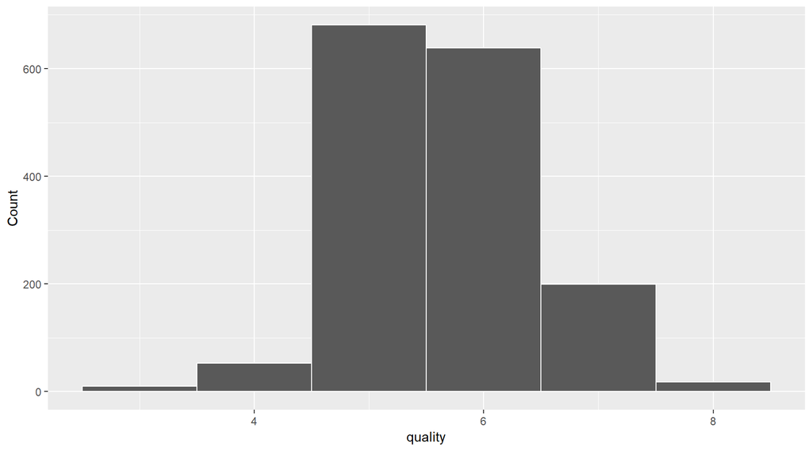

From scale 0 - 10, the observations only consist of quality 3 to quality 8. Most of the observations fall in quality 5 and 6. This observation is unbalanced, but I think we could use some normalisation to deal with this problem.

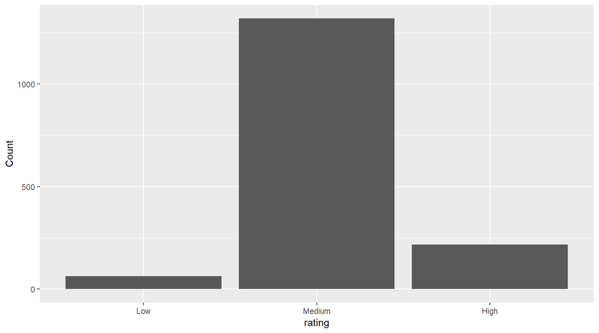

For more exploration purposes, I divide the quality into 3 ratings: Low, Med, and High Quality. Low with [3, 4] quality, Med with [5. 6] quality, and High with [7, 8] quality.

Next, we will investigate each features, starting with Fixed Acidity.

### Fixed Acidity (Tartaric Acid - g / dm^3)

Most acids involved with wine or fixed or nonvolatile (do not evaporate readily)

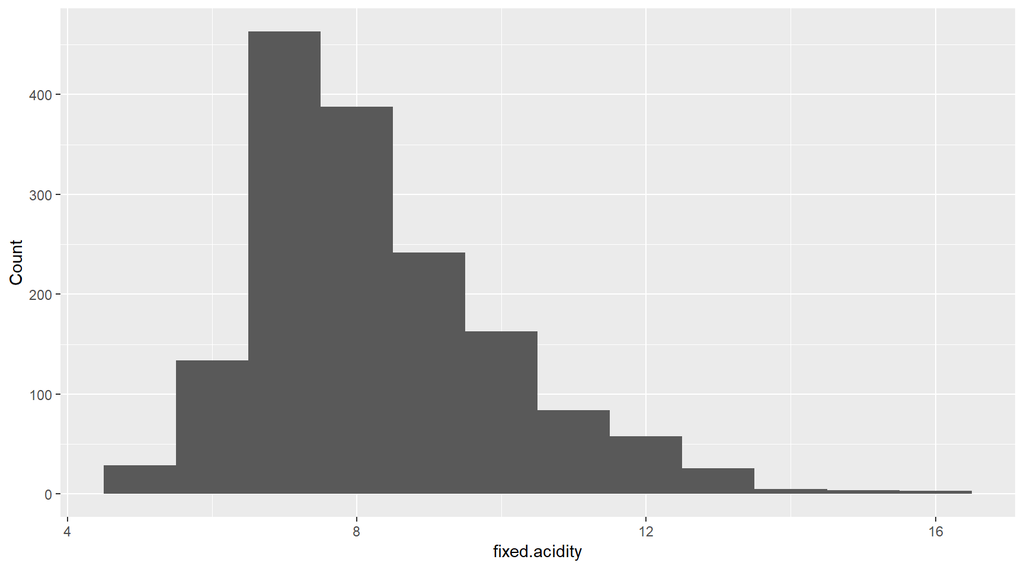

```
##    Min. 1st Qu.  Median    Mean 3rd Qu.    Max.
##    4.60    7.10    7.90    8.32    9.20   15.90
```

This looks more to a normal distribution with fixed acidity of 8 g / dm^3 in the middle.

### Volatile Acidity (Acetic Acid - g / dm^3)

The amount of acetic acid in wine, which at too high of levels can lead to an unpleasant, vinegar taste

```
## <ScaleContinuousPosition>
##  Range:
##  Limits:    0 --    1
```

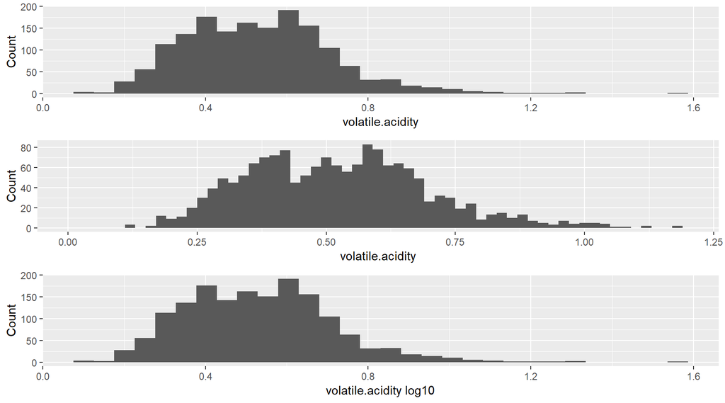

```
##    Min. 1st Qu.  Median    Mean 3rd Qu.    Max.
##  0.1200  0.3900  0.5200  0.5278  0.6400  1.5800
```

In the first plot, volatile acidity seems to be more bimodal. I changed the binwidth, and yes the second plot shows that it is definitely a bimodal distribution. Doing log transformation seems to have a little effect here for the distribution.

### Citric Acid (g / dm^3)

Found in small quantities, citric acid can add ‘freshness’ and flavor to wines

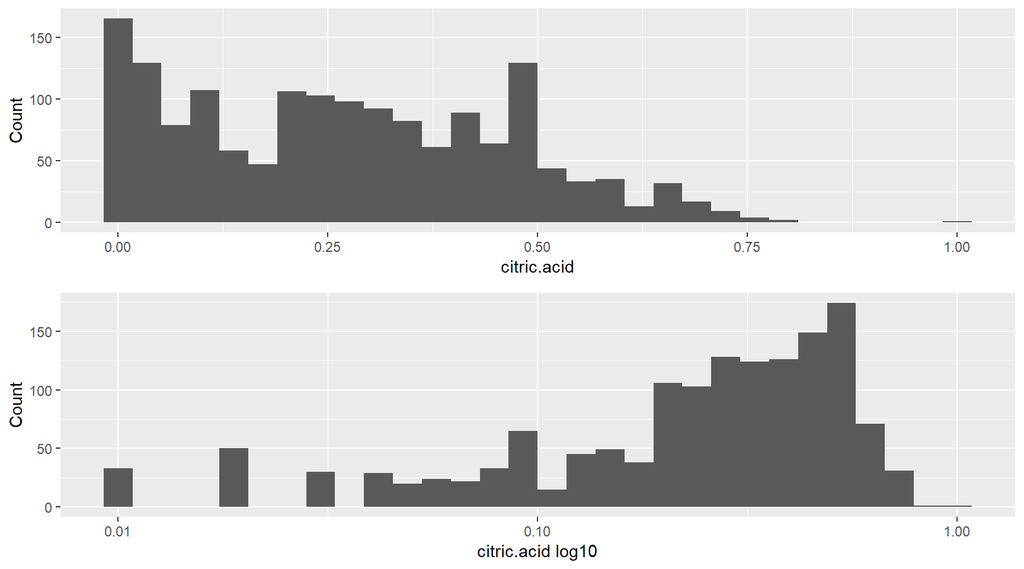

```
##    Min. 1st Qu.  Median    Mean 3rd Qu.    Max.
##   0.000   0.090   0.260   0.271   0.420   1.000
```

### Residual Sugar (g / dm^3)

The amount of sugar remaining after fermentation stops, it’s rare to find wines with less than 1 gram/liter and wines with greater than 45 grams/liter are considered sweet

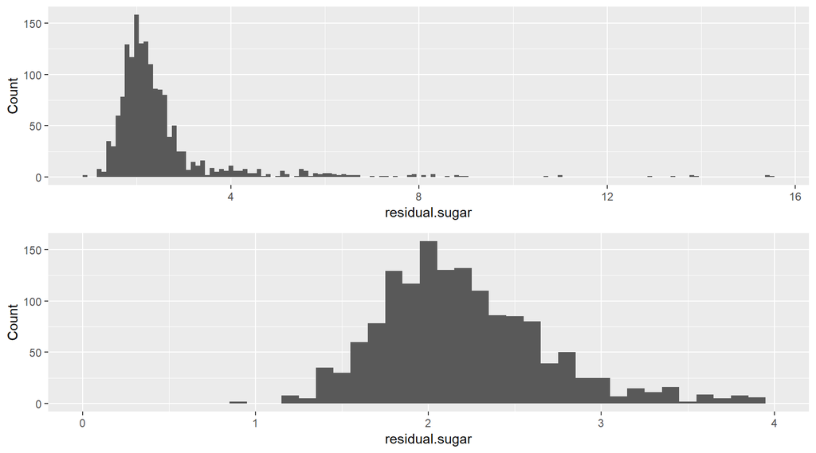

```
##    Min. 1st Qu.  Median    Mean 3rd Qu.    Max.
##   0.900   1.900   2.200   2.539   2.600  15.500
```

The residual sugar has a normal distribution with many outliers above value 4 g / dm^3. In the second plot, I limit the value to maksimum of 4 to get a closer look at the distribution.

### Chlorides (Sodium Chloride - g / dm^3)

The amount of salt in the wine

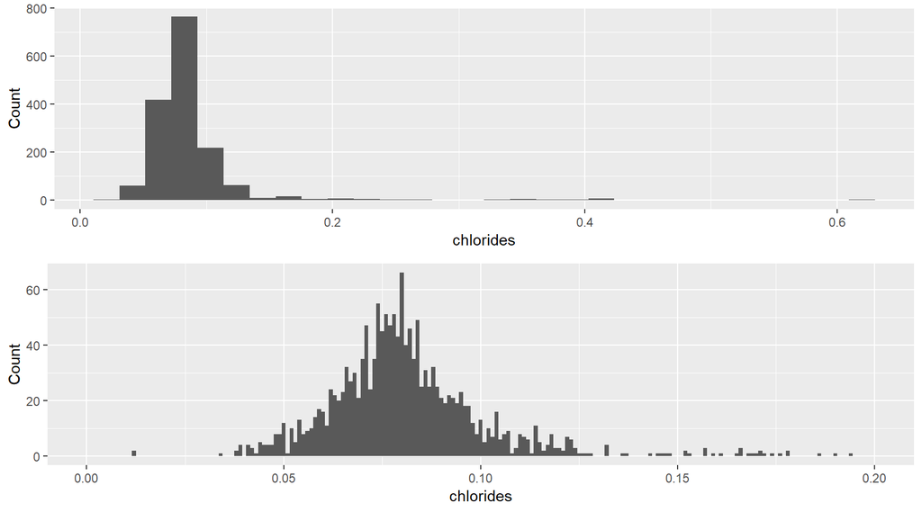

```
##    Min. 1st Qu.  Median    Mean 3rd Qu.    Max.
## 0.01200 0.07000 0.07900 0.08747 0.09000 0.61100
```

The chlorides is also a normal distribution. In the second plot, I change the binwidth into 0.001 and we can see that it is a nice normal distribution with outliers value more than 0.125.

### Free Sulfur Dioxide (mg / dm^3)

The free form of SO2 exists in equilibrium between molecular SO2 (as a dissolved gas) and bisulfite ion; it prevents microbial growth and the oxidation of wine

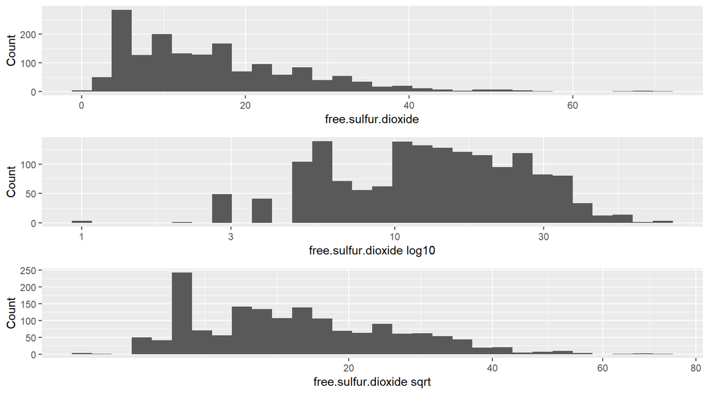

```
##    Min. 1st Qu.  Median    Mean 3rd Qu.    Max.
##    1.00    7.00   14.00   15.87   21.00   72.00
```

### Total Sulfur Dioxide (mg / dm^3)

Amount of free and bound forms of S02; in low concentrations, SO2 is mostly undetectable in wine, but at free SO2 concentrations over 50 ppm, SO2 becomes evident in the nose and taste of wine

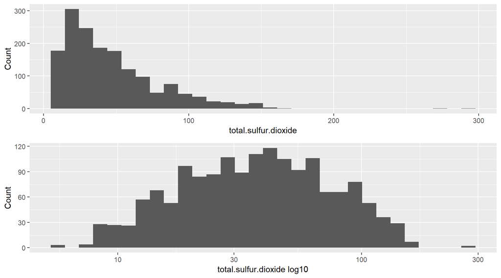

```
##    Min. 1st Qu.  Median    Mean 3rd Qu.    Max.
##    6.00   22.00   38.00   46.47   62.00  289.00
```

### Density (g / cm^3)

The density of water is close to that of water depending on the percent alcohol and sugar content

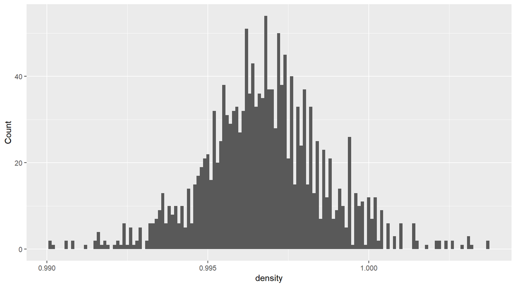

```
##    Min. 1st Qu.  Median    Mean 3rd Qu.    Max.
##  0.9901  0.9956  0.9968  0.9967  0.9978  1.0037
```

With binwidth of 0.0001, this distribution of density is a nice normal distribution.

### pH

Describes how acidic or basic a wine is on a scale from 0 (very acidic) to 14 (very basic); most wines are between 3-4 on the pH scale

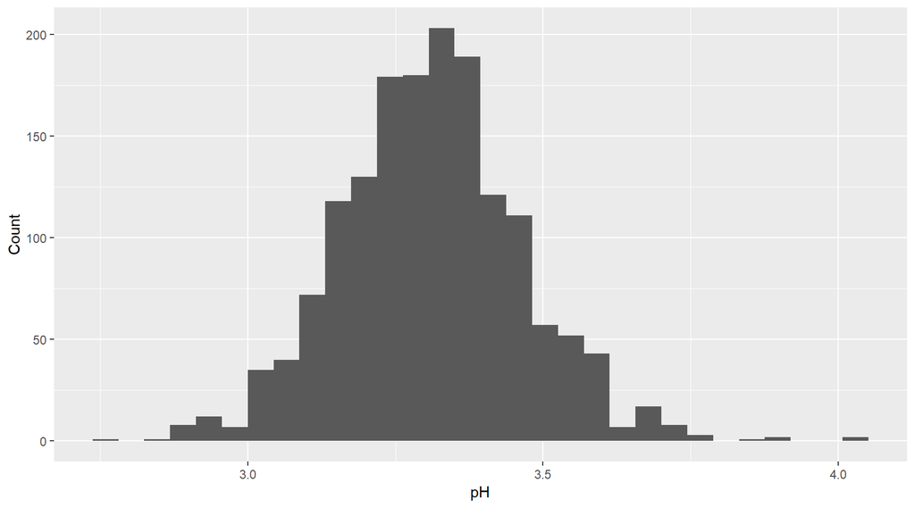

```
##    Min. 1st Qu.  Median    Mean 3rd Qu.    Max.
##   2.740   3.210   3.310   3.311   3.400   4.010
```

Our wine data is consistent with the common wine in the market, which concentrate between 3 - 4. There are some wines that are below 3 which is more acid than the common wine. I actually interested to see how pH affect the quality of the wine.

### Sulphates (Potassium Sulphate - g / dm3)

A wine additive which can contribute to sulfur dioxide gas (S02) levels, wich acts as an antimicrobial and antioxidant

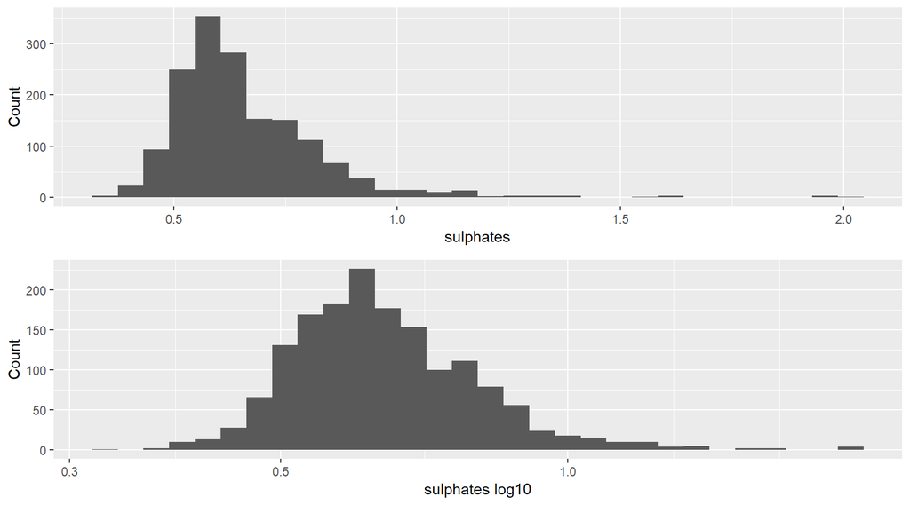

```
##    Min. 1st Qu.  Median    Mean 3rd Qu.    Max.
##  0.3300  0.5500  0.6200  0.6581  0.7300  2.0000
```

For the sulphates, it is more likely to be a normal distribution. We can get a nicer distribution with log transformation shown in the second plot. I will be using the log transformed sulphates for further analysis.

### Alcohol (% by volume)

The percent alcohol content of the wine

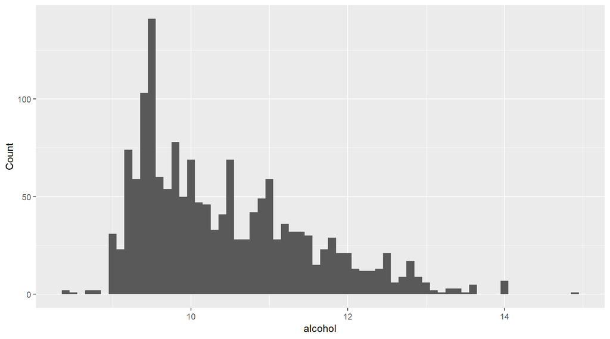

```
##    Min. 1st Qu.  Median    Mean 3rd Qu.    Max.
##    8.40    9.50   10.20   10.42   11.10   14.90
```

## Univariate Analysis

### What is the structure of your dataset?

The dataset contains of 1599 observations with 13 variables. The text from the data shows that there are no missing values. Based on our data preprocessing also shows that the variables in the data are quite normal so there is no data cleansing needed.

### What is/are the main feature(s) of interest in your dataset?

I would say that I am interested on how each attribute contribute to the quality of the red wine. Some say that wine with more citric acid and alcohol will have more quality, but we will see in the bivariate/multivariate analysis section.

### What other features in the dataset do you think will help support your investigation into your feature(s) of interest?

I might say that Residual Sugar would have an effect on the wine quality. When I drink wine with friends, some of my friends said that wine that is sweet is not wine at all. So I think this is the chance to prove that statement with data.

### Did you create any new variables from existing variables in the dataset?

I divide the quality of the wine into 3 features which I called “rating”, contains of low (3 and 4), medium (5 and 6), and high quality (7 and 8). I think this approach would help me to get more insights for further exploration.

### Of the features you investigated, were there any unusual distributions? Did you perform any operations on the data to tidy, adjust, or change the form of the data? If so, why did you do this?

No. No operations needed. As I said that the data is already cleaned and the notes in the text shows that there are no missing values. There might be some outliers, but I suspect that is just the truth. So a little bit of outliers treatment would solve that problem.

## b. Bivariate Plots Section

Let’s look at the overall correlation.

```
##  [1] "fixed.acidity"        "volatile.acidity"     "citric.acid"
##  [4] "residual.sugar"       "chlorides"            "free.sulfur.dioxide"
##  [7] "total.sulfur.dioxide" "density"              "pH"
## [10] "sulphates"            "alcohol"              "quality"
```

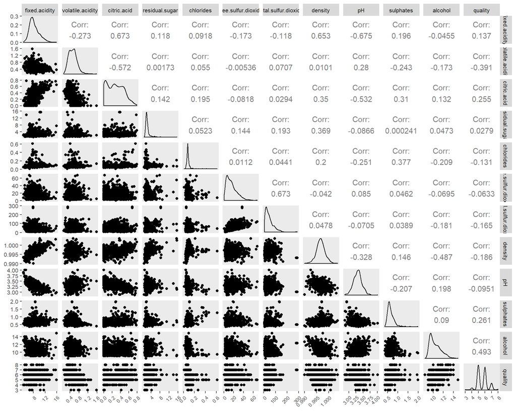

When we look at the correlation above, below is the top 4 correlation related to our main feature, quality:

1. Alcohol: 0.493
2. Volatile Acid: -0.391
3. Sulphates: 0.261
4. Citric Acid: 0.255

I also list down correlation between features that caught my interest:

1. Citric Acid & Fixed Acidity: 0.673
2. Alcohol & Density: -0.487
3. Density & Fixed Acidity: 0.653
4. Residual Sugar & Density: 0.369

Below is the distribution between alcohol and quality

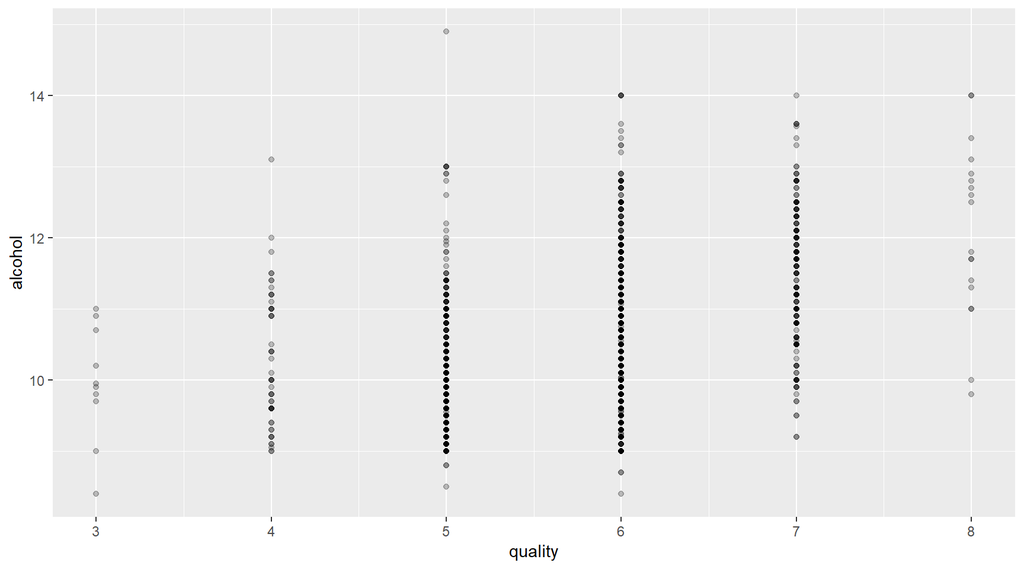

Let’s make it into jitter to reduce overplotting

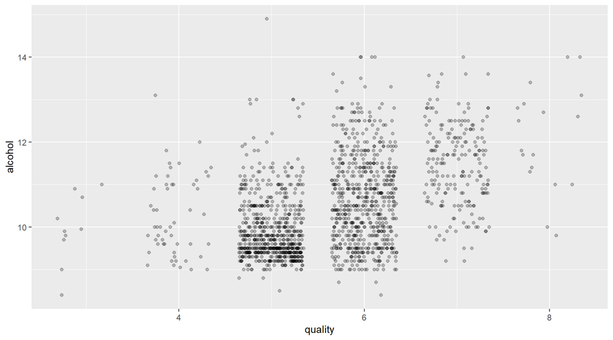

As the correlation shows that more alcohol content tends to make the quality of the wine higher. Let’s change the plot into a boxplot to see the correlation more clearly with data points.

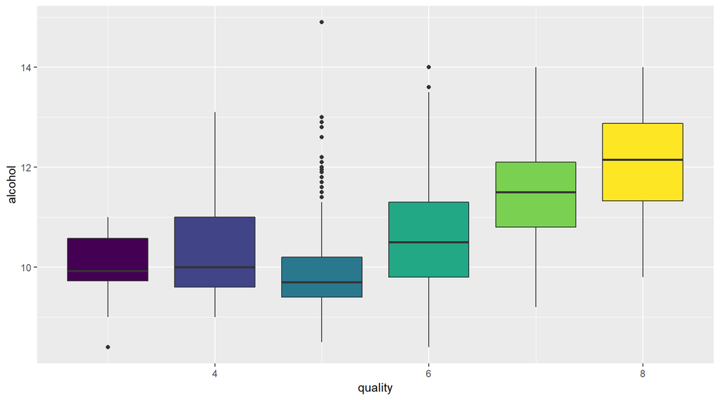

We can see that there are so many outliers in the quality 5. Maybe it is because that our data mainly fall in the Medium quality (5 and 6) so the chance of outliers would higher in that segment.  
The interesting part is that for the quality 5, the boxplot shows that there is a slight decline. I think this happens because the boxplot didn’t include the outliers and there are so many outliers in this point. When we see at the overall points, the correlation between alcohol and quality is a consistent positive.

Next, is the volatile acidity and quality.

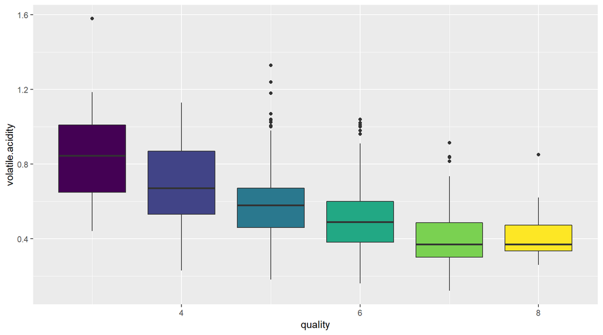

Negative correlation shows that as the volatile acidity (or acetic acid) gain, the quality of the wine is falling. Ezekeil Neeley (2004) said that the production of acetic acid will result in the concomitant formation of other, sometimes unpleasant, aroma compounds. This explains the negative correlation between volatile acidity and quality of the wine.

The third is the sulphates and quality.

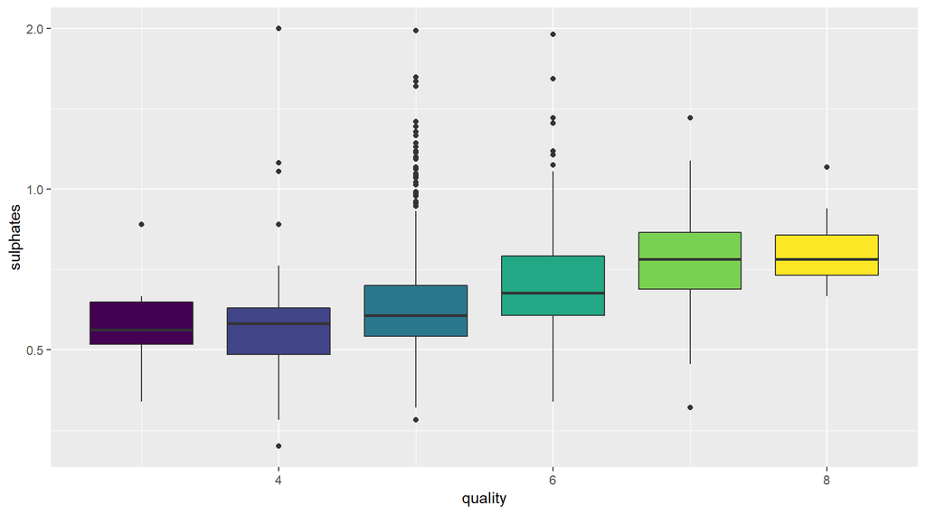

Another positive correlation. The last to show from the list is citric acid and quality.

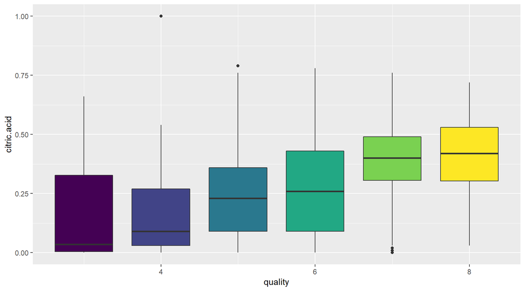

The boxplot between citric acid and quality shows a wide range distribution. Even though the number of the data in the low rating (3 and 4) not as many as medium rating (5 and 6), the interquartile seems to be wide, especially in the 3 quality.

Being the top feature that correlates highly to the quality, I will be diving deeper to alcohol feature. I will be creating a distribution using histogram as below.

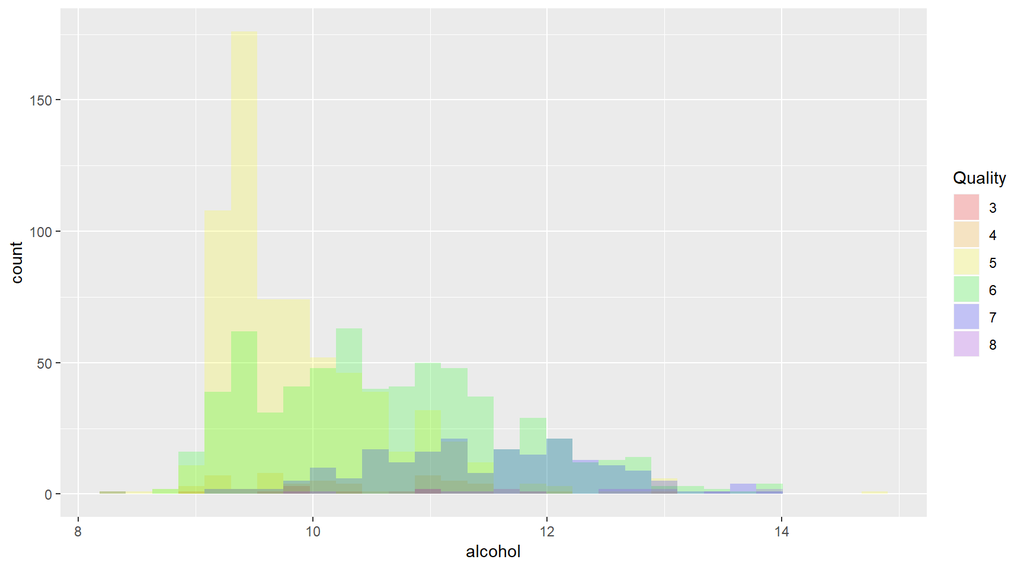

Because the data points are imbalanced between each quality, I will change the histogram plot to a density plot.

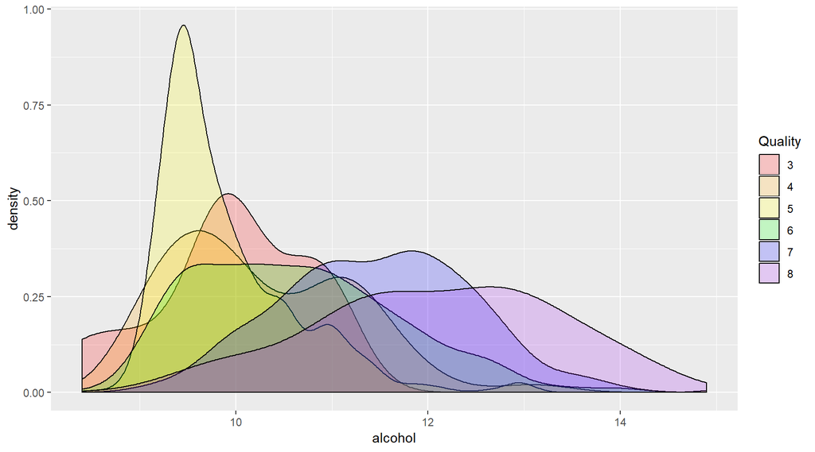

There is definitely a pattern here but it seems to crowded with 6 data points of quality. This is when the rating comes to handy.

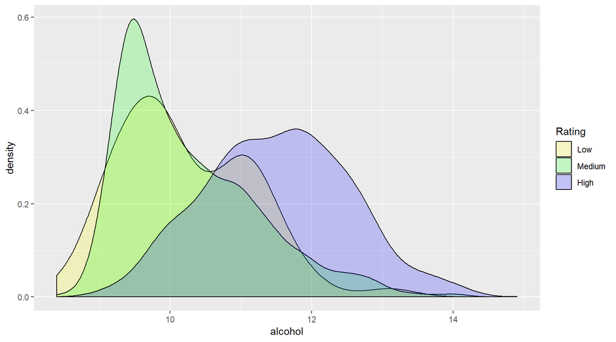

From the density plot of rating and alcohol, I can say that there is still an overlapping in the low and medium rating, which contains of 9 - 12% of alcohol. Above that, the high rating seems to be rising in the density. This is actually a nice density that explains the correlation between alcohol and quality.

Since I’ve made the density plot for alcohol, I also try to make the density plot for the other 3 features.

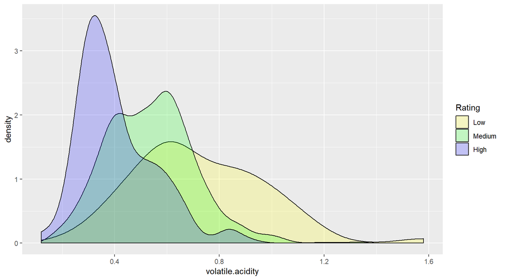

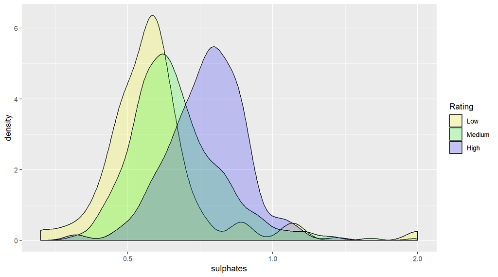

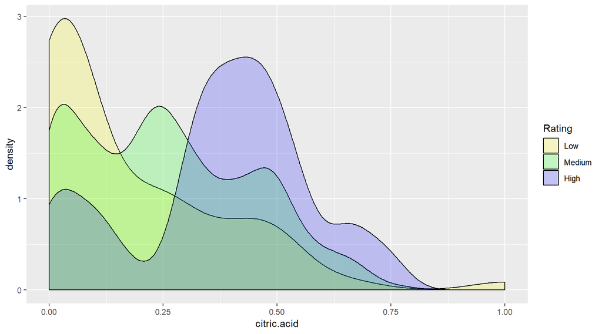

I think we see a consistent correlation here between those features.

# Bivariate Analysis

### Talk about some of the relationships you observed in this part of the investigation. How did the feature(s) of interest vary with other features in the dataset?

I am actually surprised to see residual sugar has little correlation to the quality of the wine (0.0279). The top correlation to the quality is actually alcohol (0.493). I am beginning to get curious in how alcohol and other feature affect the wine quality.

### Did you observe any interesting relationships between the other features (not the main feature(s) of interest)?

I have mentioned the list of correlation between features that interest me, especially finding that there is a relatively high negative correlation between alcohol and density. As mentioned by ETS Lab, sugar is also makes the wine denser (correlation of 0.369) which I will be diving further in these correlation in the next section, multivariate plot section.

## c. Multivariate Plots Section

This section is to answer the question that not answered in the previous section. The first plot is looking if the first and second relatively high correlation features to the quality.

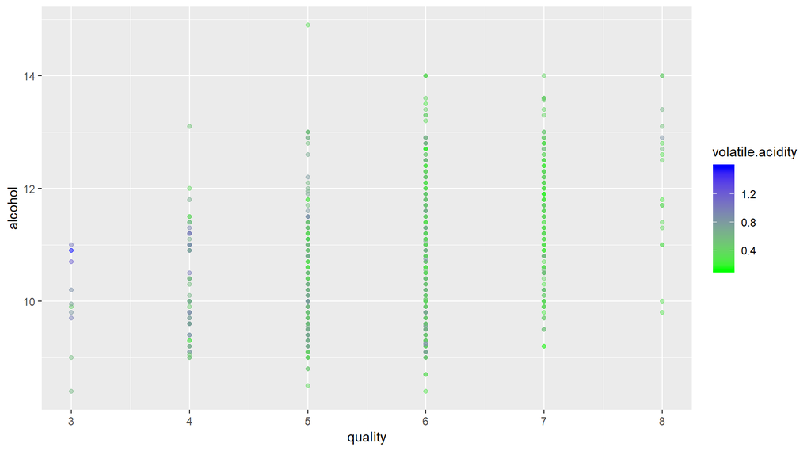

Since the plot is overplotted, I add jitter to the plot and makes it more readable.

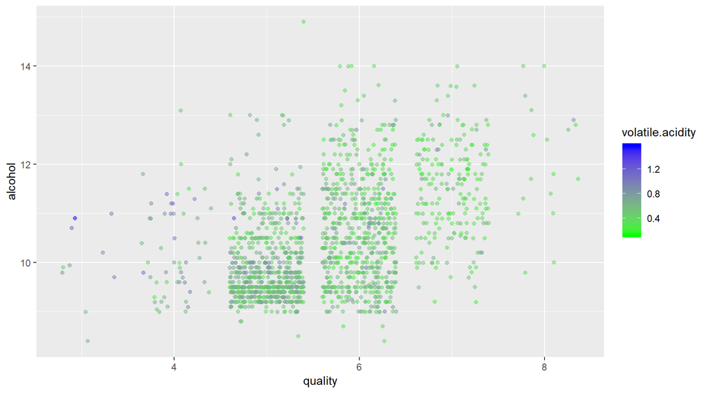

And yes, although some data points are out of correlation, we can see that overall this is still consistent, where there is positive correlation dots between alcohol and quality, and the higher the quality, the greener the color.

Next, let’s see how the quality relates to alcohol and citric acid. I separate the quality on the rating to see the plot clearer.

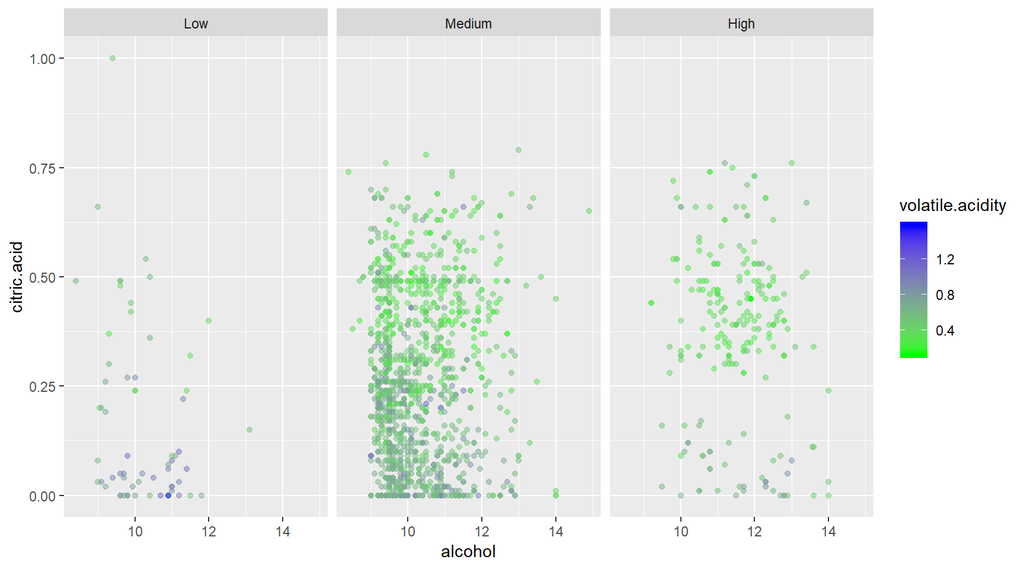

We can clearly see a pattern here where lower points of citric acid tends to group in the low quality section (also more blue in color of volatile acidity), and vice versa.

Next plot is the scatter between alcohol and citric acid, divided by colour for the rating.

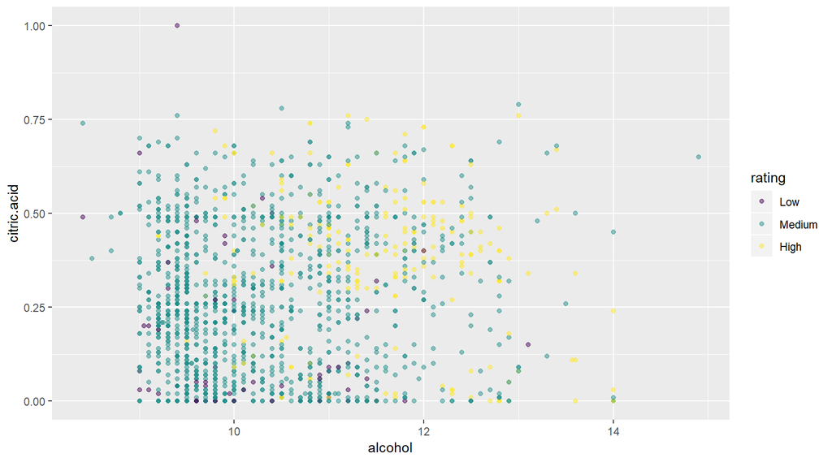

Although the range is wide (as shown in the boxplot, citric acid has a wider range data points), there is still wide group where low alcohol and citric acid tends to produce low quality wine. However, wide range of citric acid makes this plot difficult to be explained further and definitely cannot be drawn a causation.

So, how about we change the citric acid to volatile acidity?

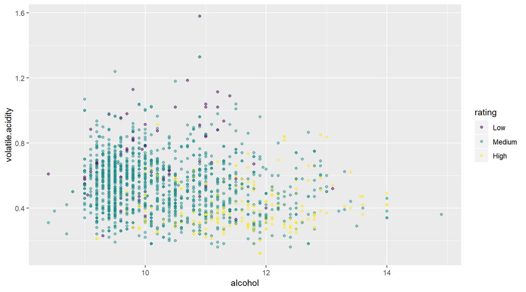

This is better since the data points tends to group into a category. And we can see a nicer group of data here where higher volatile acidity tends to produce low quality of wine, and vice versa.

The last in the list of relatively high correlation is sulphates.

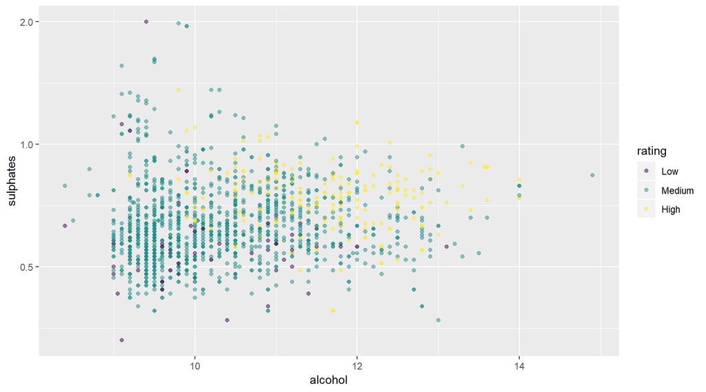

This plot contains denser group and will likely to explain more when the data is balanced between the low, medium, and high quality.